# Analyse combinatoire et dénombrement : notions de base

Diana Nurbakova

**Scénario 1 : Quelle est la probabilité d’avoir une paire au Poker ?**

Connaissez-vous *le jeu de Poker* à 52 cartes ?

*Une main* (en. *poker hand*) au poker classique (sans joker ni carte ajoutée) est composée de 5 cartes qu’un joueur constitue. Ces combinaisons de cartes peuvent avoir la force différente. La force des combinaisons est liée à la probabilité d’avoir ce type de main.

Notons que *la couleur d’une carte* désigne : pique ♠, trèfle ♣, carreau ♦ ou cœur ♥.

*Le rang d’une carte* désigne sa valeur, son niveau hiérarchique. L’ordre des cartes par force croissante est : Deux ($2$), Trois ($3$), Quatre ($4$), Cinq ($5$), Six ($6$), Sept ($7$), Huit ($8$), Neuf ($9$), Dix ($10$), Valet ($V$ ou $J$), Dame ($D$ ou $Q$), Roi ($R$ ou $K$), As ($A$).

**La paire** (en. *pair*) est une combinaison formée par *deux cartes de même rang* et trois autres cartes quelconques telles que :

- leur *rang est différent de celui de la paire* ;
- leur *rang est différent entre elles*.

Voici un exemple d’une paire : cette paire est définie par deux valets (deux cartes de même rang) et 3 autres cartes différentes au niveau de leur rang qui est aussi différent de la paire ($3$, $9$, $K$), i.e.: $3 \neq 9 \neq K \neq J$.

🂻 🃛 🃞 🂩 🂳

Quelle est la probabilité d’avoir une paire ?

> Comment calculer le nombre de configurations possibles, d’évènements réalisables, d’évènements favorables, etc. ? Souvent il s’agit d’énumération de certains objets combinatoires, du **dénombrement** (en. *counting*).

# Sans répétition

## Permutations sans répétition

**Combien de façons d’ordonner $n$ éléments ?**

**Une permutation** (en. *permutation*) de $n$ éléments est toute disposition ordonnée de ces $n$ éléments.

**Exemple 1 :** Pensez aux jeux de cartes. Vous avez obtenu une certaine main. Vous pouvez ré-organiser les cartes dans votre main mais elles restent les mêmes.

Soit $E = \{$🂶 🃙 🃝 🃅$\}$. Des permutations vont être formées d’exactement mêmes cartes en changeant leur ordre, e.g. :

- $p_1(E) = \{$🃅 🂶 🃙 🃝$\}$
- $p_2(E) = \{$🃙 🃅 🃝 🂶$\}$

**Exemple 2 :** Soit $E = \{a,b,c\}$. Combien de façons y a-t-il d’ordonner les éléments de $E$ ? ou autrement dit, combien de mots à 3 uniques lettres existe-il ?

Notons que $n =|E|= 3$.

Pour énumérer toutes les possibilités, on peut suivre la logique suivante traduite sous forme d’un arbre :

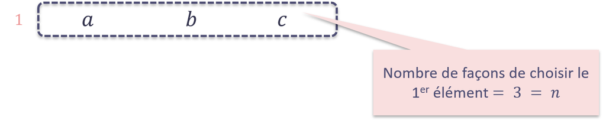

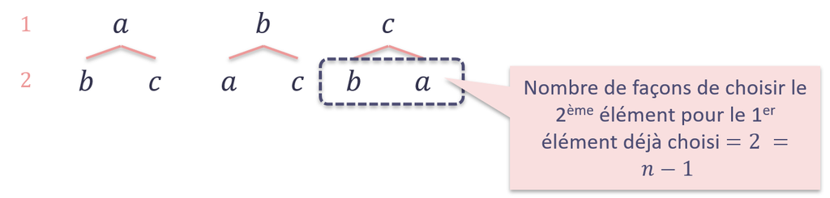

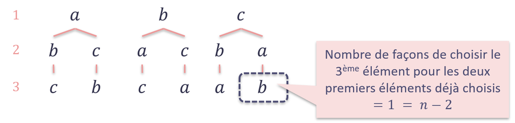

Ainsi, les permutations possibles sont : $abc$, $acb$, $bac$, $bca$, $cab$, $cba$. Nous obtenons **6** options.

Ce résultats on peut obtenir en multipliant les nombres de façons de choisir les éléments de chaque niveau sachant les éléments précédants (voir les figures ci-dessus) : $3\times 2 \times 1 = 6$ ou autrement dit $n\times (n-1)\times ... \times 1 = n! = 3! = 6$, où $n=|E|=3$.

Nous pouvons donc formuler deux propriétés suivantes :

**Propriétés :**

1. Les éléments des permutations du même ensemble $E$ sont les mêmes.
2. Le nombre de permutations d’un ensemble à $n$ éléments est :
   $$n! = 1\times 2\times ...\times n$$

Dans le `R`:

```r
# installer un package gtools si n'est pas déjà installé
if(!("gtools" %in% installed.packages()[,"Package"])){
  install.packages('gtools')
}
# charger la librairie
library(gtools)
# définir le vecteur de données d'entrée
input <- c("a", "b", "c")
# prendre toutes les permutations possibles sans répétition
permutations(n=length(input), r=length(input), v=input)
```

```
##      [,1] [,2] [,3]
## [1,] "a"  "b"  "c"
## [2,] "a"  "c"  "b"
## [3,] "b"  "a"  "c"
## [4,] "b"  "c"  "a"
## [5,] "c"  "a"  "b"
## [6,] "c"  "b"  "a"
```

```r
# calculer le nombre de permutations (option 1)
factorial(length(input))
```

```
## [1] 6
```

```r
# prendre le nombre de ligne dans le résultat de permutations (option 2)
nrow(permutations(n=length(input), r=length(input), v=input))
```

```
## [1] 6
```

## Arrangements sans répétition

Considérons un exemple suivant.

**Exemple 3 :** Quatre personnes participent au Cross de l’INSA : Karine, Michel, Kevin et Amélie. Combien de façons existe-t-il pour définir la 1ère et la 2ème place de la compétition ?

Notons que $n = 4$ et le nombre d’éléments à choisir est $k = 2$ (1ère et 2ème place).

Supposons que Karine est arrivée la 1ère.

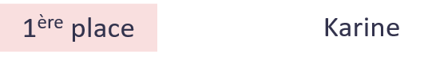

Quelles sont les options pour la 2ème place en sachant la 1ère ?

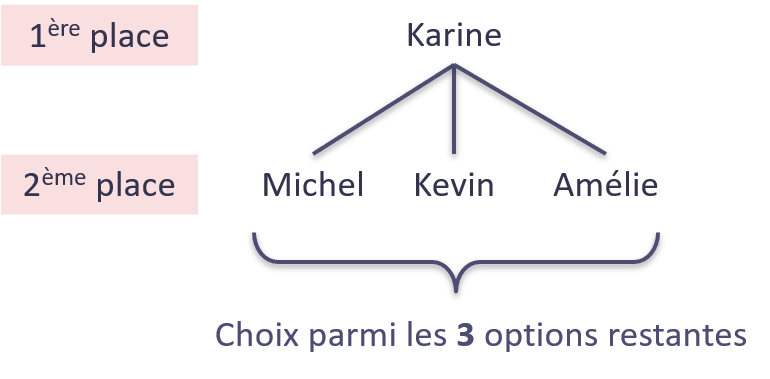

Rajoutons le cas où c’est Michel qui est arrivé le 1er.

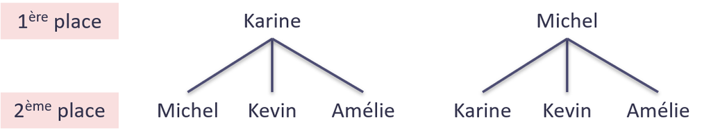

On peut voir que les participants sont les mêmes. Cependant, il y a une différence car l’ordre compte. Ainsi, $<Karine, Michel> \neq <Michel, Karine>$ :

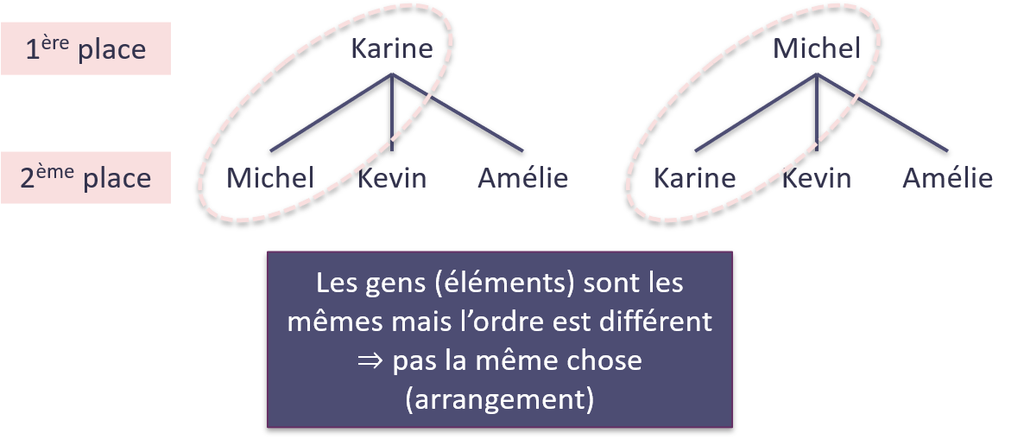

Maintenant, si on regarde tous les cas, on obtient des options suivates :

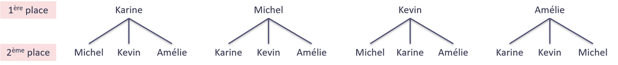

Parmi toutes ces options, il y a 4 possibilités de choisir la 1ère place, ou $n$.

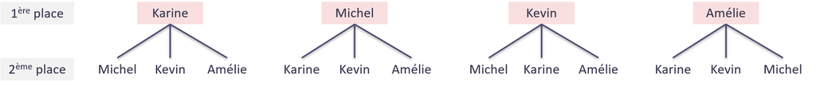

Comme on peut voir sur les images, pour chaque 1ère place choisie, il y a 3 possibilités ($n-1$) pour choisir la 2ème place.

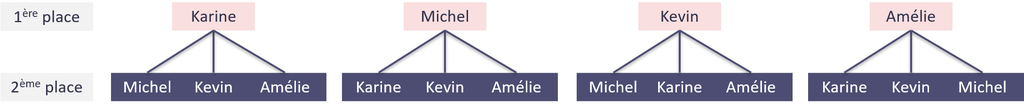

Alors, le nombre total d’options peut être calculé comme le produit : $4 \times 3 = 12$ ou $n \times (n-1) = n\times (n-k+1) = 12$.

On appelle ce type de disposition ordonnée de $k$ éléments *un arrangement*.

**Un arrangement sans répétition** (en. $k$-*permutation*) de $k$ éléments parmi les $n$ de l’ensemble $E$ est toute disposition ordonnée de ces $k$ éléments.

Considérons un exemple suivant :

**Exemple 4 :** Soit $E = \{a,b,c,d\}$. Trouvez tous les arrangements possibles de 3 éléments parmi 4 et calculez leur nombre.

En suivant la logique présentée dans l’Exemple 2, nous pouvons arriver aux cas suivants :

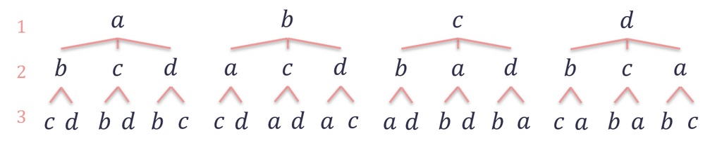

On peut les réécrire sous la forme suivante :

$abc$ $abd$ $acb$ $acd$ $adb$ $adc$

$bac$ $bad$ $bca$ $bcd$ $bda$ $bdc$

$cba$ $cbd$ $cab$ $cad$ $cda$ $cdb$

$dbc$ $dba$ $dcb$ $dca$ $dab$ $dac$

Regardons combien d’options il existe pour chaque niveau :

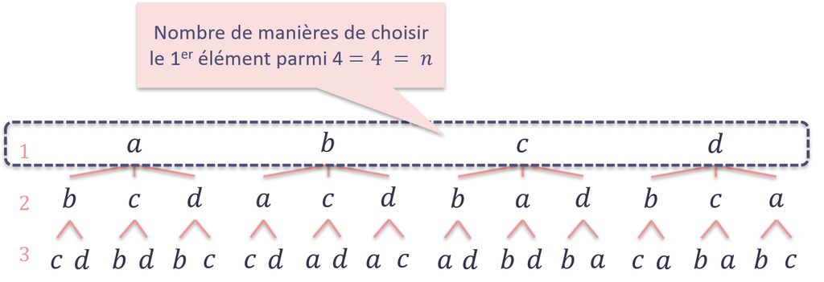

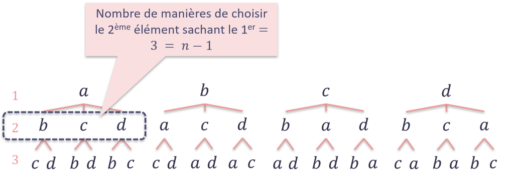

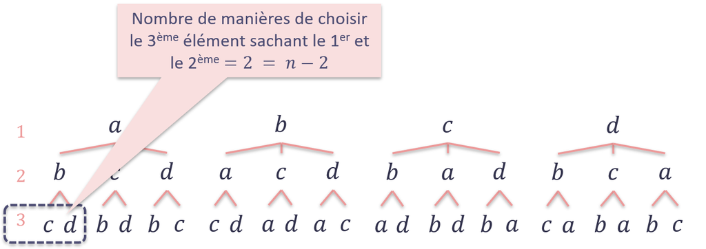

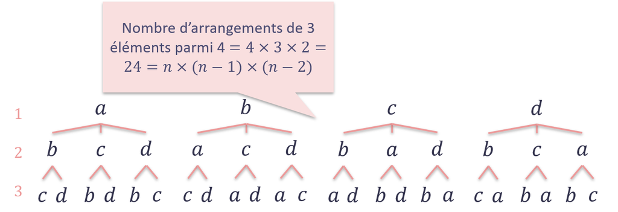

Donc, le nombre d’arrangements de 3 éléments parmi 4 est : $4\times 3 \times 2 = 24$ ou autrement dit : $n\times (n-1) \times (n-2) = n\times (n-1) \times (n-k+1)$, où $n=4$, $k=3$.

Nous pouvons formuler les propriétés d’arrangements :

**Propriétés :**

1. Un arrangement sans répétition de $n$ éléments pris parmi $n$ éléments ($A^n_n$) est une permutation.
2. Le nombre d’arrangements sans répétition de $k$ éléments parmi $n$ éléments :
   $$A^k_n = \frac{n!}{(n-k)!} = n\times (n-1) \times ... \times (n-k+1)$$

Dans le `R`:

```r
# installer un package gtools si n'est pas déjà installé
if(!("gtools" %in% installed.packages()[,"Package"])){
  install.packages('gtools')
}
# charger la librairie
library(gtools)
# définir le vecteur de données d'entrée
input2 <- c("a", "b", "c", "d")
# prendre 3 parmi 4 sans répétition en prenant en compte l'ordre
permutations(n=length(input2), r=3, v=input2)
```

```
##       [,1] [,2] [,3]
##  [1,] "a"  "b"  "c"
##  [2,] "a"  "b"  "d"
##  [3,] "a"  "c"  "b"
##  [4,] "a"  "c"  "d"
##  [5,] "a"  "d"  "b"
##  [6,] "a"  "d"  "c"
##  [7,] "b"  "a"  "c"
##  [8,] "b"  "a"  "d"
##  [9,] "b"  "c"  "a"
## [10,] "b"  "c"  "d"
## [11,] "b"  "d"  "a"
## [12,] "b"  "d"  "c"
## [13,] "c"  "a"  "b"
## [14,] "c"  "a"  "d"
## [15,] "c"  "b"  "a"
## [16,] "c"  "b"  "d"
## [17,] "c"  "d"  "a"
## [18,] "c"  "d"  "b"
## [19,] "d"  "a"  "b"
## [20,] "d"  "a"  "c"
## [21,] "d"  "b"  "a"
## [22,] "d"  "b"  "c"
## [23,] "d"  "c"  "a"
## [24,] "d"  "c"  "b"
```

```r
# calculer le nombre de permutations comme le nombre de ligne dans le résultat
nrow(permutations(n=length(input2), r=3, v=input2))
```

```
## [1] 24
```

## Combinaisons sans répétition

Reprenons l’exemple du Cross de l’INSA (Exemple 3) en changeant la question.

**Exemple 5 :** Quatre personnes participent au Cross de l’INSA : Karine, Michel, Kevin et Amélie. Parmi ces 4 personnes, deux ont reçu un t-shirt blanc à la fin de la course. Combien de possibilités de donner un t-shirt blanc à 2 participants ?

Notons que dans ce cas-là, **l’odre ne compte pas**, c’est-à-dire : $<Karine, Michel> = <Michel, Karine>$, $<Karine, Amélie> = <Amélie, Karine>$, etc.

Listons toutes les paires possibles sans prendre en compte de l’ordre :

- Karine & Michel
- Karine & Kevin
- Karine & Amélie
- Michel & Kevin
- Michel & Amélie
- Kevin & Amélie

**Une combinaison sans répétition** (en. *permutation*) de $k$ éléments parmi les $n$ de l’ensemble $E$ est toute disposition **non ordonnée** de ces $k$ éléments.

Reprenons l’Exemple 4 en changeant la question.

**Exemple 6 :** Soit $E = \{a,b,c,d\}$. Combien de combinaisons de 3 éléments sans répétition ? (Orloff and Bloom 2014)

Notons que lorsqu’il s’agit de combinaisons, l’orde d’éléments dans une disposition ne compte pas, i.e. $abc = cba$, mais $ab\mathbf{c} \neq ab\mathbf{d}$.

Listons les combinaisons possibles : $abc$, $abd$, $acd$, $bcd$.

Comparons maintenant avec les arrangements de 3 éléments du même ensemble $E$ :

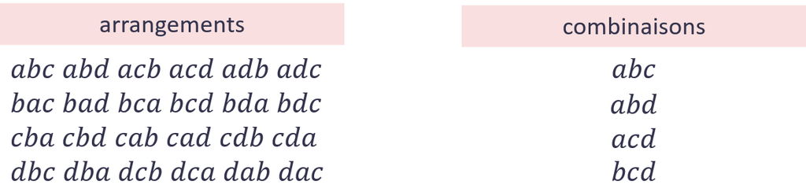

Rappelons que $A^3_4 = \frac{4!}{(4-3)!} = 4\times 3 \times 2 = 24$.

Remarquons que dans la liste des arrangements, on peut distinguer des éléments qui sont des permutations de 3 éléments. Ci-dessous, les permutations des éléments $a$, $b$ et $c$ parmi les arrangements sont surlignées. Il s’agit de : $abc$, $acb$, $bac$, $bca$, $cba$, $cab$.

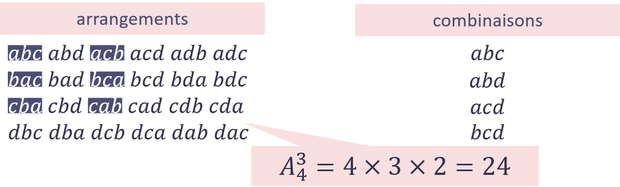

Pour rappel, le nombre de permutations de 3 éléments est : $3! = 3\times 2\times 1 = 6$.

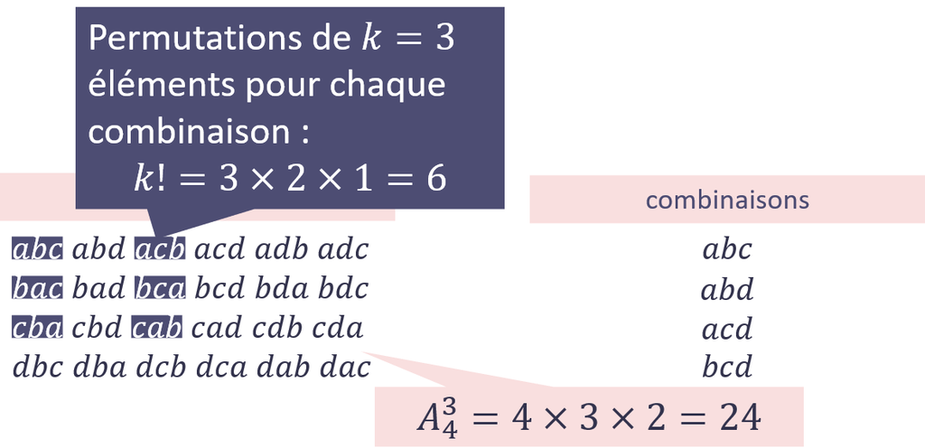

Alors, nous pouvons remarquer que le nombre de combinaisons $k$ éléments parmi $n$ est donné par : $\frac{A^k_n}{k!}$.

Formulons les propriétés des combinaisons :

**Propriétés :**

1. Deux combinaisons sont différentes si elles contiennent au moins un élément différent.
2. Le nombre de combinaisons sans répétition de $k$ éléments parmi $n$ éléments :
   $$C^k_n = \begin{pmatrix}n \\ k\end{pmatrix} = \frac{n!}{k!(n-k)!} = \frac{A^k_n}{k!} = \frac{n\times (n-1)\times ... \times (n-k+1)}{k!}$$

Dans le `R`:

```r
# le nombre de combinaisons de 3 parmi 4 (coefficient binomial)
choose(4, 3)
```

```
## [1] 4
```

### Propriétés de combinaisons

Nous allons démontrer quelques propriétés de combinaisons sans répétition.

**Propriété (1) :**

$$C^{n-k}_n = \frac{n!}{(n-k)!(n-(n-k)!)} = \frac{n!}{(n-k)!k!} = C^k_n$$

**Propriété (2) :** le nombre de choix d’un élément parmi $n$

$$C^{1}_n = \begin{pmatrix}n \\ 1\end{pmatrix} = \begin{pmatrix}n \\ n-1 \end{pmatrix} = C^{n-1}_n = n$$

**Propriété (3) :**

$$C^{k}_n = C^{k-1}_{n-1} + C^{k}_{n-1}$$

**Démontrons :**

$$C^{k-1}_{n-1} = \frac{(n-1)!}{(k-1)! \left((n-1) - (k-1)\right)!} = \frac{(n-1)!}{(k-1)! \left(n- k\right)!}$$

$$C^{k}_{n-1} = \frac{(n-1)!}{k! \left((n-1) - k)\right)!} = \frac{(n-1)!}{k! \left(n- k-1\right)!}$$
Alors :

$$C^{k-1}_{n-1} + C^{k}_{n-1} = \frac{(n-1)!}{(k-1)! \left(n- k\right)!} + \frac{(n-1)!}{k! \left(n- k-1\right)!} = \frac{(n-1)!}{(k-1)! \left(n- k-1\right)!}\left(\frac{1}{n-k} + \frac{1}{k}\right) =$$
$$= \frac{(n-1)!}{(k-1)! \left(n- k-1\right)!}\left(\frac{k}{(n-k)k} + \frac{n-k}{k(n-k)}\right) = \frac{(n-1)!}{(k-1)! \left(n- k-1\right)!}\times \frac{k + n - k}{(n-k)k} =$$

$$= \frac{(n-1)!}{(k-1)! \left(n- k-1\right)!}\times \frac{n}{(n-k)k} = \frac{(n-1)!\times n}{\left((k-1)!\times k\right) \left((n- k-1)!\times (n-k)\right)} = \frac{n!}{k!(n-k)!} = C^k_n$$

**Propriété (4) :**

$$C^{k}_{n} + C^{k+1}_{n} = \begin{pmatrix} n \\ k \end{pmatrix} + \begin{pmatrix} n \\ k+1 \end{pmatrix} = \begin{pmatrix} n+1 \\ k+1 \end{pmatrix} = C^{k+1}_{n+1}$$

**Démontrons :**

$$C^{k}_{n} + C^{k+1}_{n} = \frac{n!}{k!(n-k)!} + \frac{n!}{(k+1)!(n-(k+1))!} = \frac{n!}{k!(n-k-1)!}\times \left(\frac{1}{n-k} +\frac{1}{k+1}\right) =$$

$$=\frac{n!}{k!(n-k-1)!}\times \left(\frac{k+1}{(n-k)(k+1)} + \frac{n-k}{(k+1)(n-k)}\right) = \frac{n!}{k!(n-k-1)!}\times \left(\frac{k+1 + n-k}{(n-k)(k+1)}\right) =$$
$$= \frac{n!}{k!(n-k-1)!}\times \frac{n+1}{(n-k)(k+1)} = \frac{n!\times (n+1)}{\left(k!\times (k+1)\right) \left((n-k-1)! \times (n-k)\right)} = \frac{(n+1)!}{(k+1)!(n-k)!} =$$

$$=\frac{(n+1)!}{(k+1)!\left((n+1) - (k+1)\right)!} = C^{k+1}_{n+1}$$

**Propriété (5) :** *Formule du binôme* : $\forall (a,b) \in \mathbb{R}^2$ (ensemble des couples de nombres réels), $\forall n \in \mathbb{N}$ :

$$(a+b)^n = \sum^{n}_{k=0}C^k_na^kb^{n-k}$$
$C^k_n$ est aussi appelé **coefficient binomial**.

Considérons un exemple de $n=2$ :

$$(a+b)^2 = C^0_2 a^0 b^{2-0} + C^1_2 a^1 b^{2-1} + C^2_2 a^2 b^{2-2} = C^0_2 a^0 b^{2} + C^1_2 a^1 b^{1} + C^2_2 a^2 b^{0} = C^0_2 b^{2} + C^1_2 ab + C^2_2 a^2 =$$

$$=\frac{2!}{0!(2-0)!}\times b^2 + \frac{2!}{1!(2-1)!}\times ab + \frac{2!}{2!(2-2)!}\times a^2 = b^2 + 2ab + a^2$$

### Exemple de calcul

**Exemple 7 :** Pour créer un robot, nous avons besoin de 2 moteurs et 2 modules de relais. Nous avons le choix parmi 8 moteurs et 5 modules de relais. Combien de combinaisons existe-t-il ?

Notons que dans ce cas-là, l’ordre de choix des composants n’a pas d’importance. Donc, il s’agit des combinaisons.

Pour rappel, la formule de base pour le nombre de combinaisons sans répétition est : $C^k_n = \begin{pmatrix}n \\ k\end{pmatrix} = \frac{n!}{k!(n-k)!}$.

Il est possible de calculer le nombre de choix de moteurs et modules de relais séparément avant de calculer le résultat :

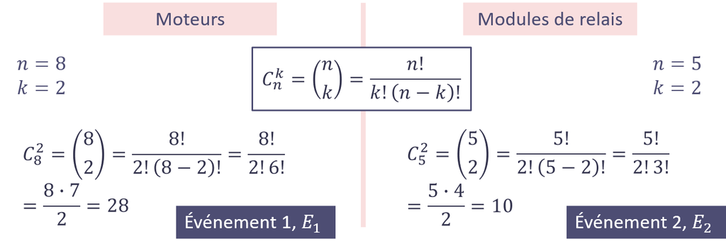

Le nombre total de combinaisons va être calculé comme un produit de résultats pour les moteurs et les modules de relais : $C^2_8 \times C^2_5 = 28 \times 10 = 280$

On peut voir que dans ce cas, il s’agit de faire *un choix de moteur* **et** *un choix de module de relais*. Aurement dit, pour chaque choix de moteur parmi 28, il existe 10 choix de module de relais, d’où l’utilisation du **produit** du nombre de ces choix. Ceci est considéré comme un des **principes fondementaux de dénombrement** (en. *fundamental counting principle* ou *counting rule* ou *basic counting rule*).

**Principe fondemental de dénombrement** (en. *fundamental counting principle* ou *counting rule* ou *basic counting rule*)**

Soit $E_1, E_2, ..., E_k$ une suite d’évènements. L’évènement $E_1$ peut se réaliser de $n_1$ façons possibles. Une fois que $E_1$ est réalisé, l’évènement $E_2$ peut se réaliser de $n_2$ façons possibles, etc. Le nombre total de choix possibles pour les $k$ évènements est donné par le produit du nombre de choix de chacun d’évènements : $n_1 \times n_2 \times ... \times n_k$

De point de vue des ensembles, il s’agit du cardinal du produit cartésien d’une suite d’ensembles finis : $card\left(E_1\times E_2 \times ... \times E_k\right) = \prod_{i=1}^{k}card(E_i)$

# Avec répétition

Jusqu’à là, nous avons considéré des cas “*sans répétition*”, c’est-à-dire que les éléments n’étaient pas remis sur place avant le prochain choix, on pouvait utiliser chaque élément qu’une seule fois.

Dans cette section, nous allons voir le cas *avec répétition*, c’est-à-dire nous **ne** retirons **pas** les éléments (les options restent disponibles).

## Arrangements avec répétition

Considérons un exemple d’un code.

**Exemple 8 :** Nous cherchons à trouver le code composé de 7 chiffres. Nous savons que les trois premiers chiffres sont 116. Combien d’options possibles existe-t-il? Les chiffres peuvent se répéter.

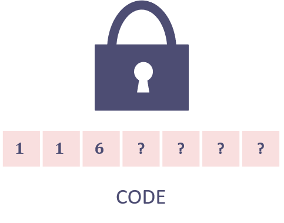

Est-ce que l’ordre d’éléments est important ?

$$\left.
\begin{array}{ll}
116 \ 3542 \\
116 \ 5423
\end{array}
\right \} \text{pas le même code} \Rightarrow \text{l'ordre est important}$$

Donc, il s’agit des *arrangements avec répétition*.

Lorsqu’il s’agit du code à 7 chiffres, dont nous connaissons les trois premiers, il suffit de trouver les quatre derniers.

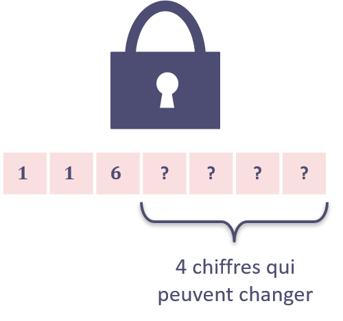

La question qui se pose maintenant est : combien d’options pour choisir chacun de ces 4 chiffres ?

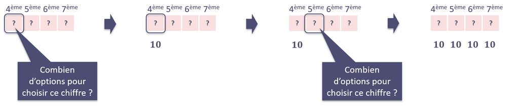

Ainsi, pour chaque position, il existe 10 possibilités.

Le nombre total d’options est donnée par le produit : $10 \times 10 \times 10 \times 10 = 10^4$

**Un arrangement avec répétition** de $k$ éléments parmi les $n$ de l’ensemble $E$ est toute disposition ordonnée de $k$ éléments, non nécessairement distincts.

**Propriétés :**

Le nombre d’arrangements avec répétition de $k$ éléments parmi $n$ éléments :
$$\underbrace{n\times n \times ... \times n}_{k\text{ fois}} = n^k$$

## Combinaisons avec répétition

Considérons un exemple suivant.

**Exemple 9 :** Il existe des vaccins de 4 types. Trois personnes souhaitent se faire vacciner. Chaque personne reçoit un vaccin, possiblement du même type. Quel est le nombre de configurations possibles ?

A chaque tirage, il faut qu’on se rassure d’avoir les mêmes options possibles pour le tirage suivant tant qu’on n’a pas tiré aussez d’éléments. Pour le faire, on peut imaginer qu’après chaque tirage, on “rajoute” un élement retiré.

rajout

nombre de choix

Init

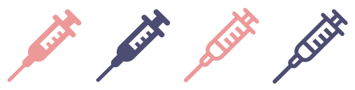

4

1er

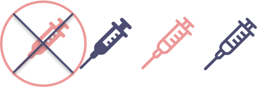

5

2ème

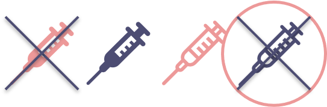

6

3ème

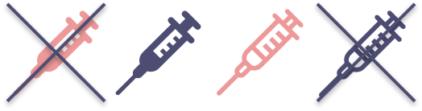

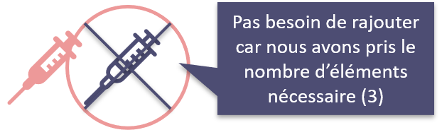

6

Alors, il s’agit de choisir 3 éléments parmi 6 :
$$C^3_6 = \frac{6!}{3!(6-3)!} = \frac{6\times 5\times 4 \times 3\times 2\times 1}{(3\times 2)(3\times 2)} = 5\times 4 = 20 = C^3_{4+3-1}$$

Une autre façon de penser ici va être : comment est-ce qu’on peut répartir 3 peronnes (patient) selon 4 groupes (vaccins) ?

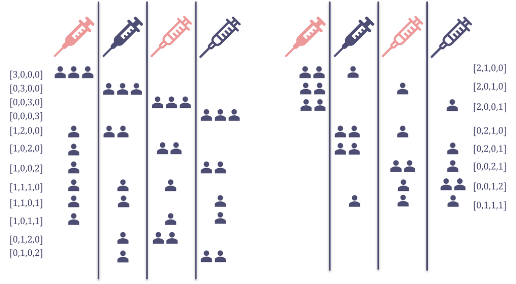

On peut représenter les mêmes configurations de la façon suivante :

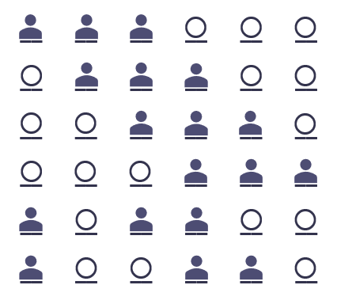

L’image ci-dessus correspond à 6 premières lignes de la figure précédente. Le symbole $\circ$ est utilisé pour marquer les séparateurs de groupes.

Le calcul revient au même : le choix de 3 positions parmi 6 possibles, i.e. $C^3_6$ : en sachant les positions des patients, nous allons savoir une configuration. On retrouve les mêmes 20 combinaisons.

**Une combinaison avec répétition** de $k$ éléments parmi les $n$ de l’ensemble $E$ est toute disposition non ordonnée de ces $k$ éléments, non nécessairement distincts.

**Propriétés :**

Le nombre de combinaisons avec répétition de $k$ éléments parmi $n$ éléments :
$$C^k_{n+k-1} = \begin{pmatrix} n+k-1 \\ k\end{pmatrix} = \frac{(n+k-1)!}{k!(n-1)!}$$

## Permutations avec répétition

Considérons un exemple.

**Exemple 10 :** Il existe 10 doses de vaccins de 4 types : deux vaccins de type $A$, 3 vaccins de type $B$, 4 vaccins de type $C$ et 1 vaccin de type $D$. Quel est le nombre de possibilités à mettre 10 vaccins répartis en 4 types à 10 personnes qui font la queue ? Notons que les éléments du même type ne sont pas distincts.

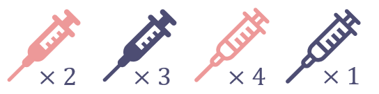

Est-ce que l’ordre compte ? *oui*.

Il s’agit de choisir 10 éléments parmi 10 en tenant compte de l’ordre, donc ce sont des permutations.

Si on ne tient pas de compte de type de vaccins, le nombre de permutations sera : $n! = 10!$

Lorsque les éléments du même type ne sont pas dinstincts :

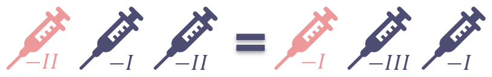

Il faut predre en compte les permutations parmi les éléments du même type :

- $n_1! = 2!$
- $n_2! = 3!$
- $n_3! = 4!$
- $n_4! = 1!$

Donc, le nombre total de permutations avec répétition est :
$$\frac{10!}{2!\times 3! \times 4! \times1!} = \frac{10\times 9\times 8\times 7\times 6\times 5\times 4\times 3\times 2\times 1}{(2\times 1)\times (3\times 2\times 1)\times (4\times 3\times 2\times 1) \times 1} = 10\times 9\times 4\times 7\times 5 = 12600$$

Soit il existe $l$ catégories, les éléments de l’ensemble $E$ se répartissent en ces catégories de la façon que $n_1+n_2+...+n_l=n$, où $n_i$ est le nombre d’éléments dans la catégorié $i$.

**Une permutation avec répétition** de $n$ éléments répartis en $l$ catégories est toute disposition ordonnée de $n$ éléments qui contient $n_i$ éléments de chaque catégories $i$.

**Propriétés :**

1. “*Répétition*” au niveau de catégories (types) : un type d’élément peut être présent plusieurs fois
2. Le nombre de permutations avec répétition :
   $$\frac{n!}{n_1! \times n_2! \times ... \times n_l!}$$

# Bilan

Résumons les calculs dans un tableau ci-dessous :

|  | sans répétition | avec répétition |
| --- | --- | --- |
| avec ordre | $$A^k_n = \frac{n!}{(n_k)!}$$ | $$n^k$$ |
|  | $$A^n_n = n!$$ | $$\frac{n!}{n_1!\times n_2!\times ... \times n_l!}$$ |
| sans ordre | $$C^k_n = \frac{n!}{k!(n-k)!}$$ | $$C^k_{n+k-1} = \frac{(n+k-1)!}{k!(n-1)!}$$ |

# Etude de cas : Quelle est la probabilité d’avoir une paire au Poker ? (Scénario 1)

Reprenons le scénario d’exemple du début. Pour rappel, nous cherchons la probabilité d’avoir une paire comme une main au Poker.

Le paquet standard de Poker est constituer de 52 cartes ($n=52$) réparties en 4 couleurs : piques, trèfles, coeurs et carreaux. Donc, il y a 13 cartes de chaque couleur (enseigne).

### Choix de 5 cartes parmi 52

Une main au Poker est formée de 5 cartes. Notons que l’ordre n’a pas d’importance dans ce cas-là. Ainsi, nous pouvons calculer le nombre total de combinaisons possibles pour choisir 5 cartes (une main) parmi 52 :
$$C^5_{52} = \begin{pmatrix}52 \\ 5\end{pmatrix} = \frac{52!}{5!(52-5)!} = \frac{52!}{5!47!} = \frac{52\times 51\times 50\times 49\times 48}{5\times 4\times 3\times 2\times 1} =$$
$$= 52\times 51 \times 10\times 49\times 2 = \mathbf{2598960}$$
ou en utilisant la fonction de `R` :

```r
# nombre de combinaisons de 5 parmi 52
choose(n=52, k=5)
```

```
## [1] 2598960
```

On peut également vérifier juste le résultat de la division des factorielles avec `R` :

```r
factorial(52)/(factorial(5)*factorial(47))
```

```
## [1] 2598960
```

### Choix d’une paire

Les conditions qu’une main doit satisfaire pour être considérée comme une paire au Poker s’appliquent à 2 parties de cette main :

1. 2 cartes formant la paire
2. 3 cartes qui restent

##### 1. Choix de 2 cartes pour former une paire

Soit $rang = \{A, K, Q, J, 10, 9, 8, 7, 6, 5, 4, 3, 2\}$ les valeurs des cartes, $|rang| = 13$. Soit $couleur = \{$ ♠, ♣, ♦, ♥ $\}$ les couleurs de cartes, $|couleur| = 4$.

Une paire est déterminée par :

- **sa valeur** : choix de 1 parmi 13, i.e. $C^1_{13} = \begin{pmatrix}13 \\ 1\end{pmatrix} = 13$
- **les couleurs** de ses cartes : choix de 2 parmi 4, i.e. $C^2_{4} = \begin{pmatrix}4 \\ 2\end{pmatrix} = 6$

Listons toutes les combinaisons possibles de couleurs d’une paire (l’ordre ne compte pas) :

- ♦, ♣
- ♦, ♥
- ♦, ♠
- ♣, ♥
- ♣, ♠
- ♠, ♥

Alors, le nombre de choix de 2 cartes déterminant une paire est donné par :

$$C^1_{13} \times C^2_{4} = 13\times 6 = 78$$

##### 2. Choix de 3 cartes qui restent

Les contraintes sur le choix de 3 cartes autre que la paire sont :

- **les valeurs différentes de celle de la paire** : le choix est limité par $13-1 = 12$ valeurs possibles (sauf celle de la paire)
- **les valeurs différentes entre elles** : le choix de 3 parmi 12 (voir la condition précédente), i.e.
  $$C^3_{12} = \begin{pmatrix}12 \\ 3\end{pmatrix} = \frac{12!}{3!(12-3)!} = \frac{12!}{3!9!} = \frac{12\times 11\times 10}{3\times 2} = 2\times 11\times 10 = 220$$
- **les couleurs sont libres** : le choix de 3 parmi 4 **avec répétition**, i.e. $4^3 = 64$

En regroupant, on obtient que le nombre de choix de 3 cartes restantes de la main est :
$$C^3_{12}\times 4^3 = 220 \times 64 = 14080$$

##### Total pour une paire

Donc, le nombre de configurations pour avoir une main de 5 cartes avec une paire parmi 52 cartes :
$$\underbrace{C^1_{13} \times C^2_{4}}_{2\text{ cartes}}\times \underbrace{C^3_{12}\times 4^3}_{3\text{ autres cartes}} = 78\times 14080 = \mathbf{1098240}$$

### Probabilité d’avoir une paire

# Liens utiles

1. Jeremy Orloff, and Jonathan Bloom. *18.05 Introduction to Probability and Statistics*. Spring 2014. Massachusetts Institute of Technology: MIT OpenCourseWare, https://ocw.mit.edu. License: Creative Commons BY-NC-SA.
2. [Combinaisons avec répétition](https://www.youtube.com/watch?v=1crNnZkIvac)

# References

Orloff, Jeremy, and Jonathan Bloom. 2014. “18.05 Introduction to Probability and Statistics. MIT OpenCourseWare.” 2014. https://ocw.mit.edu/courses/mathematics/18-05-introduction-to-probability-and-statistics-spring-2014/.